# Intro to RMarkdown

9/23/2020

## Before we get to Rmarkdown, what is markdown?

- markdown is mini-language designed for designing documents. It allows users to have the functionality of a word processor - different fonts, bullet points, tables, etc - but written completely in plain text
- markdown has been used for years(since the early 90s), but because of its steep learning curve many choose to avoid it

## Rmarkdown

- Rmarkdown is a flavor of markdown repurposed by Rstudio. Rmarkdown was designed for programming notebooks, an environment where you can execute code *and* write in plain text. The R notebooks we’ve been using all use markdown.
- R notebooks can be “knit” into reports. These reports are highly customizeable with a huge number of output formats, including word documents and powerpoint presentations
- markdown can be used for blogs/websites, conference posters, and scientific publications
- the slides we have been using for class have all been made through R Markdown

## Benefits of Rmarkdown

- document your code much easier, as its easier to write comments and longer explanations in plain text
- create a report/presentation that is descriptive as well as dynamic; a new version of the report can be generated with out having to remake figures and move them around
- templated reports - if you commonly run an analysis, set up an Rmarkdown notebook such that all you need is input data and the same figures/tables will be generated.
- reproducibility: you know exactly what code you used to make a specific plot.
- Rmarkdown is probably one of the best and most useful features of the R programming language

## layout of a notebook cell

- We’ve briefly covered how to use R notebooks, but we’ll go into more detail now about how it all works

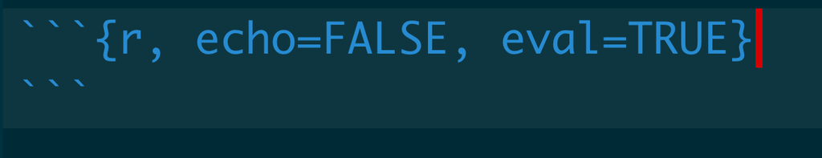

- within the curly brackets for each cell, we set parameters on how the *output* should look like. In this case we set `echo=FALSE` which means we don’t want the the code cell to be printed, and `eval=TRUE` mean, run this chunk of code.
- These parameters only affect the cell in which they are set.
- as you may have noticed from the exercise notebooks, cells can be named, by adding a title right after the `r` part of the cell header

## layout of a notebook cell

- to globally change settings for all chunks, you must have a chunk names `setup` as the first chunk of the notebook
- a complete list of options is available [here](https://rstudio.com/wp-content/uploads/2015/03/rmarkdown-reference.pdf)

## changing parameters for all cells

- to globally change a setting in rmarkdown, make a cell at the beginning of your document named setup
- within this chunk set options by using the `opts_...` functions from the `knitr` library

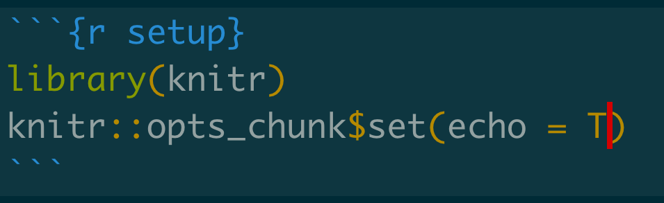

- within this `setup` chunk, we can change the working directory for the notebook with the following command

```
knitr::opts_knit$set(root.dir = 'some_path')
```

## the `knitr` library

- `knitr` is the package for the actual R code that converts R markdown into a rendered format. We generally don’t need to use it beyond formatting notebook parameters.

## changing non-cell parameters

- We can use functions from `knitr` to control a wide range of output
- for example, changing the root(working directory)

````r
#```{r setup}
library(knitr)
opts_knit$set(root.dir = '/Users/swamyvs/personal/')
#```
````

## changing parameters globally

- we can use a similar syntax as before to globally change parameters for all chunks

````r
#```{r setup}
library(knitr)
opts_chunk$set(echo = F)
#```
````

## RMarkdown in the context of plotting

- Rmarkdown is crucial for plotting;
- when making plots in RMarkdown, each cell defines the plotting environment for making a plot, in terms of the physical space a plot can take up (the units are in inches)

````r
#```{r, fig.height=1, fig.width=1}
#```
ggplot(mtcars) +
  geom_point(aes(mpg, disp)) +
  ggtitle('Plot 1')
````

## RMarkdown in the context of plotting

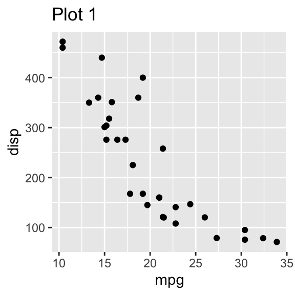

````r
#```{r, fig.height=3, fig.width=3}
#```
ggplot(mtcars) +
  geom_point(aes(mpg, disp)) +
  ggtitle('Plot 1')
````

## using external images

- you can link directly to an image via its path relative to the notebook, using the following syntax: `![Caption for Figure](path/to/image)`
- examples `![This is a Heatmap](../src/complex_heatmap_example.png)`

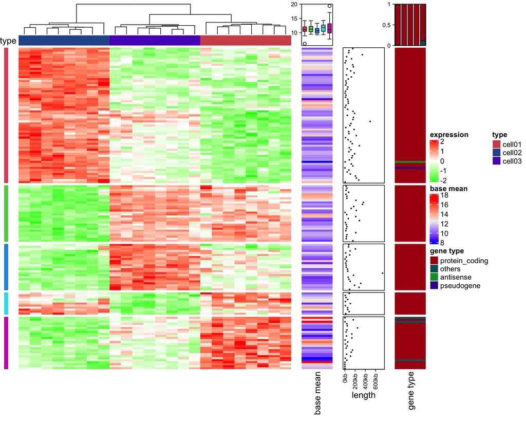

## using external images

- images can also be used through a notebook chunk with the `include_graphics` function from `knitr`

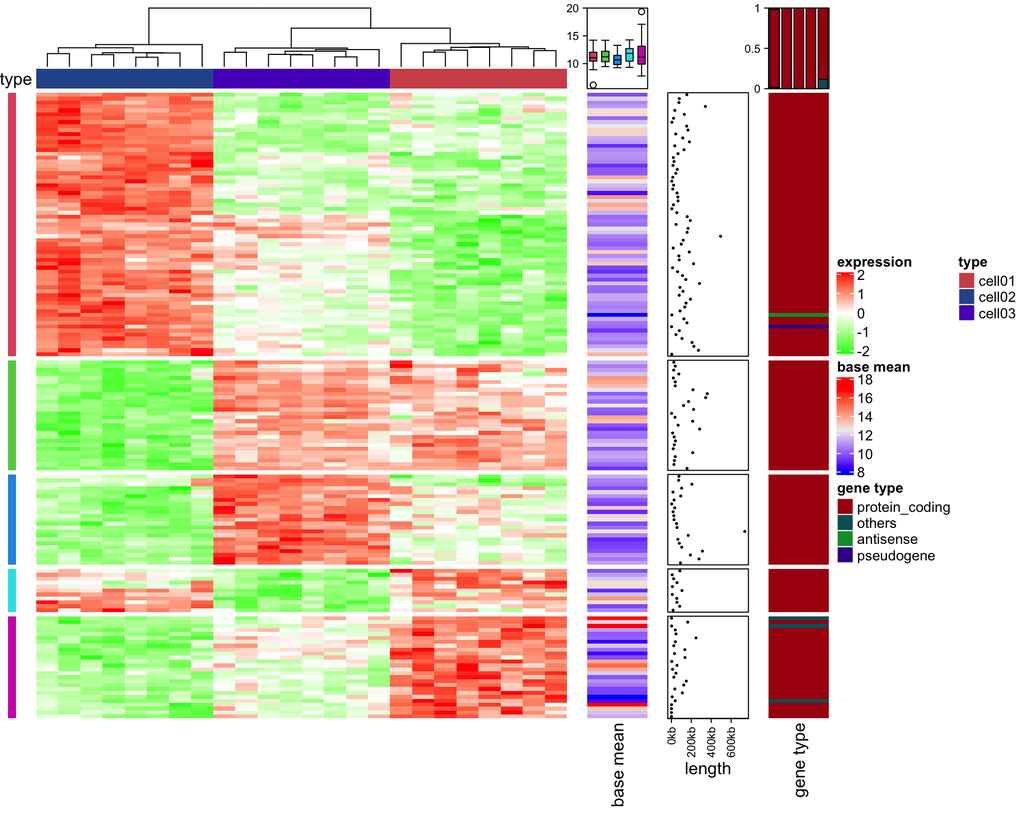

```r
knitr::include_graphics('../src/complex_heatmap_example.png')
```

- this is useful for when you want to take advantage of some of the chunk formatting options offered by `knitr`

## rendering tables

- the `knitr` package provides the `kable` function to embed nice looking tables

```r
kable(iris[1:5, ])
```

| Sepal.Length | Sepal.Width | Petal.Length | Petal.Width | Species |
| --- | --- | --- | --- | --- |
| 5.1 | 3.5 | 1.4 | 0.2 | setosa |
| 4.9 | 3.0 | 1.4 | 0.2 | setosa |
| 4.7 | 3.2 | 1.3 | 0.2 | setosa |
| 4.6 | 3.1 | 1.5 | 0.2 | setosa |
| 5.0 | 3.6 | 1.4 | 0.2 | setosa |

## rendering tables

- there are many other functions from libraries for making tables. A particularly useful one is `DT`, which creates an interactive table

```r
DT::datatable(mpg)
```

|  | manufacturer | model | displ | year | cyl | trans | drv | cty | hwy | fl | class |
| --- | --- | --- | --- | --- | --- | --- | --- | --- | --- | --- | --- |
| 1 | audi | a4 | 1.8 | 1999 | 4 | auto(l5) | f | 18 | 29 | p | compact |
| 2 | audi | a4 | 1.8 | 1999 | 4 | manual(m5) | f | 21 | 29 | p | compact |
| 3 | audi | a4 | 2 | 2008 | 4 | manual(m6) | f | 20 | 31 | p | compact |
| 4 | audi | a4 | 2 | 2008 | 4 | auto(av) | f | 21 | 30 | p | compact |
| 5 | audi | a4 | 2.8 | 1999 | 6 | auto(l5) | f | 16 | 26 | p | compact |
| 6 | audi | a4 | 2.8 | 1999 | 6 | manual(m5) | f | 18 | 26 | p | compact |
| 7 | audi | a4 | 3.1 | 2008 | 6 | auto(av) | f | 18 | 27 | p | compact |
| 8 | audi | a4 quattro | 1.8 | 1999 | 4 | manual(m5) | 4 | 18 | 26 | p | compact |
| 9 | audi | a4 quattro | 1.8 | 1999 | 4 | auto(l5) | 4 | 16 | 25 | p | compact |
| 10 | audi | a4 quattro | 2 | 2008 | 4 | manual(m6) | 4 | 20 | 28 | p | compact |

[output cut: 224 more lines]

## other useful features

- automatic citation management: refer to each reference as a tag that gets automatically formatted when the document is generated
- Rmarkdown `a comprehensive annotation of mRNA transcripts across the human body [-@gtex_consortium_genetic_2017]`
- text output `a comprehensive annotation of mRNA transcripts across the human body (13)`
- ordering is automatically generated, and formatting can be set at the beginning of each document to match specific styles, IE like that specified by a journal

## other useful features

- add inline code to text - dynamically generate numbers in a report
- Rmarkdown

```r
we found `r toString(NUMBER_OF_GENES)` differentially expressed genes
```

- text output

```
we found 2000 differentially expressed genes
```

## output formats

- out of the box, Rmarkdown converts documents to `html` format, like these slides. With a few extra packages, they can be converted to `pdf` or `docx`.
- the same document can be converted to multiple output formats, which are set in the `yaml` header of the document

```r
---
title: "Intro to RMarkdown"
author: "Vinay Swamy"
date: "9/23/2020"
output: ioslides_presentation
---
```

- this is the output format I used for the slides for this course

## output formats

```
---
title: "Intro to RMarkdown"
author: "Vinay Swamy"
date: "9/23/2020"
output: pdf_document
___
```

## extensions to Rmarkdown

- Other developers have created packages to create different types of media using Rmarkdown as the formatting language.
- `blogdown` is a popular package for making websites, where the page layout can be specified in Rmarkdown
- `posterdown` is a package for making scientific posters using Rmarkdown. We’ll be covering and using this package today.

## using `posterdown`

- poster down is remarkably easy to use. install the package and set the output in the document header as `output: posterdown::posterdown_html`.
- a few other settings can be tweaked in the yaml like including a logo or setting the number of columns